# Optimización bayesiana de hiperparámetros

Joaquín Amat Rodrigo j.amatrodrigo@gmail.com

Abril, 2020

Versión PDF: [Github](https://github.com/JoaquinAmatRodrigo/Estadistica-con-R)

Más sobre ciencia de datos: cienciadedatos.net o [joaquinamatrodrigo.github.io](https://joaquinamatrodrigo.github.io/)

# Introducción

La mayoría de modelos de *machine learning* tienen una serie de parámetros que no pueden aprenderse de los datos, sino que tienen que ser establecidos previo entrenamiento. Ha estos parámetros se les suele conocer como *hiperparámetros*.

Dado que no existe forma de conocer de antemano cuáles son los valores adecuados, la única forma de identificarlos es probando diferentes combinaciones y evaluarlas mediante métodos de validación por *resampling* (*cross-validation*, *bootstrapping*). A este proceso se le conoce como *model tuning*.

Dos de las estrategias más empleadas son *grid search* y *random search*. En la primera, los valores estudiados de cada hiperparámetro se distribuyen de forma uniforme dentro de un rango delimitado por el analista. En el segundo caso, los datos son aleatorios dentro de ese rango.

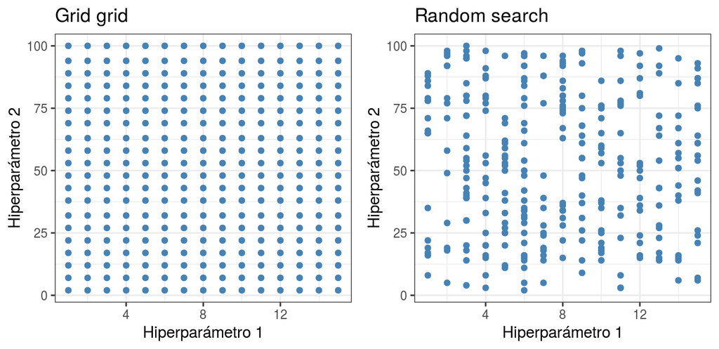

Aunque estas dos estrategias son totalmente válidas y generan buenos resultados, sobretodo cuando se tiene criterio para acotar el rango de búsqueda, comparten una carencia común: ninguna tiene en cuenta los resultados obtenidos hasta el momento, lo que les impide focalizar la búsqueda en las regiones de mayor interés y evitar regiones innecesarias. Una alternativa es la búsqueda de hiperparámetros con métodos de **optimización bayesiana**.

En términos generales, la optimización bayesiana de hiperparámetros consiste en crear un modelo probabilístico en el que el valor de la función objetivo es la métrica de validación del modelo (*rmse*, *auc*, precisión..). Con esta estrategia, se consigue que la búsqueda se vaya redirigiendo en cada iteración hacia las regiones de mayor interés. El objetivo final es reducir el número de combinaciones de hiperparámetros con las que se evalúa el modelo, eligiendo únicamente los mejores candidatos. Esto significa que, la ventaja frente a las otras estrategias mencionadas, se maximiza cuando el espacio de búsqueda es muy amplio o la evaluación del modelo es muy lenta.

Los paquetes `rBayesianOptimization` y `ParBayesianOptimization` permiten combinar fácilmente el proceso de optimización bayesiana con el entrenamiento de de cualquier modelo.

# MLR3 y ParBayesianOptimization

```r
library(ParBayesianOptimization)
library(mlr3verse)
```

## Datos

Se emplea los datos sobre el precio de viviendas disponible en el paquete `AmesHoising`.

```r
library(AmesHousing)
library(tidyverse)

datos <- make_ames()
# Se emplean únicamente las variables:
variables <- c("Sale_Price", "Bldg_Type", "Neighborhood", "Year_Built",
               "Gr_Liv_Area", "Full_Bath", "Year_Sold", "Lot_Area", "Central_Air",
               "Heating", "Latitude", "Longitude")
datos <- datos %>%
         select(one_of(variables))
```

```r
task_datos <- TaskRegr$new(
                id = "task_datos",
                backend = datos,
                target = "Sale_Price"
              )

set.seed(1234)
rsmp_holdout <- rsmp("holdout", ratio = 0.8)
rsmp_holdout$instantiate(task = task_datos)

# Índices train
id_train <- rsmp_holdout$train_set(i = 1)
# Índices test
id_test <- rsmp_holdout$test_set(i = 1)
task_train <- task_datos$clone()$filter(id_train)
task_test  <- task_datos$clone()$filter(id_test)
```

**Predictores**

```r
# Se define la variable respuesta y los predictores.
var_respuesta <- "Sale_Price"
# Para este modelo se emplean todos los predictores disponibles.
predictores   <- task_train$feature_names
```

## Función de scoring

```r
scoring_function <- function(num.trees, min.node.size) {

  learner <- lrn("regr.ranger", num.threads = 4)
  learner$param_set$values <- list(num.trees = num.trees,
                                   min.node.size = min.node.size
                               )
  resampling_cv <- rsmp("cv", folds = 5)
  metrica       <- msr("regr.rmse")

  resampling <- resample(
                  task         = task_train,
                  learner      = learner,
                  resampling   = resampling_cv,
                  store_models = FALSE
               )

  score <- resampling$aggregate(measures = metrica)

  # Si la métrica es un error, dado que el proceso es de maximización, se convierte
  # en negativo.
  score <- -score

  return(list(Score = score))
}
```

## Espacio de búsqueda

```r
limites <- list(
              # Emplear sufijo L si son valores enteros
              num.trees = c(100L, 2000L),
              min.node.size = c(1L, 100L)
           )
```

## Optimización

```r
set.seed(123)
bayes_opt <- bayesOpt(
                FUN = scoring_function,
                bounds = limites,
                initPoints = 10,
                iters.n = 20,
                iters.k = 1,
                otherHalting = list(timeLimit = 5*60)
            )
```

```r
bayes_opt
```

```
## Class: bayesOpt
##
##                  Epochs: 18
##              Iterations: 28
##     Average FUN Seconds: 7.86
##     Highest FUN Seconds: 19.08
## Final Upper Conf. Bound: 0.08171149
##              GP Updated: TRUE
##             Stop Status: Stopped Early. See $stopStatus
```

## Resultados

```r
bayes_opt$scoreSummary
```

| Epoch | Iteration | num.trees | min.node.size | gpUtility | acqOptimum | inBounds | Elapsed | Score | errorMessage |
| --- | --- | --- | --- | --- | --- | --- | --- | --- | --- |
| 0 | 1 | 1495 | 65 | NA | FALSE | TRUE | 5.092 | -36768.35 | NA |
| 0 | 2 | 985 | 50 | NA | FALSE | TRUE | 3.111 | -36128.34 | NA |
| 0 | 3 | 1871 | 16 | NA | FALSE | TRUE | 12.479 | -32960.49 | NA |
| 0 | 4 | 136 | 99 | NA | FALSE | TRUE | 0.526 | -38976.39 | NA |
| 0 | 5 | 819 | 10 | NA | FALSE | TRUE | 4.354 | -32854.81 | NA |
| 0 | 6 | 1638 | 27 | NA | FALSE | TRUE | 6.149 | -34160.84 | NA |
| 0 | 7 | 1329 | 55 | NA | FALSE | TRUE | 3.738 | -36231.98 | NA |
| 0 | 8 | 1147 | 82 | NA | FALSE | TRUE | 2.763 | -37917.46 | NA |
| 0 | 9 | 404 | 40 | NA | FALSE | TRUE | 1.444 | -35739.82 | NA |
| 0 | 10 | 543 | 73 | NA | FALSE | TRUE | 1.757 | -37442.32 | NA |

[output cut: 18 more lines]

```r
getBestPars(bayes_opt)
```

```
## $num.trees
## [1] 1442
##
## $min.node.size
## [1] 1
```

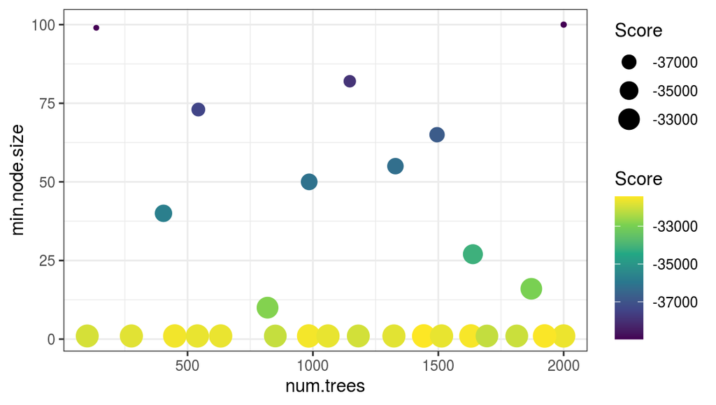

```r
library(gganimate)
ggplot(data = bayes_opt$scoreSummary,
       aes(x = num.trees, y = min.node.size, size = Score, color = Score)) +
  geom_point() +
  scale_color_viridis_c() +
  theme_bw()
```

## Paralelización

```r
library(doParallel)

cl <- makeCluster(4)
registerDoParallel(cl)
clusterExport(cl, c('task_train'))
clusterEvalQ(cl, expr = {library(mlr3verse)})

set.seed(123)
bayes_opt <- bayesOpt(
                FUN = scoring_function,
                bounds = limites,
                initPoints = 10,
                iters.n = 20,
                iters.k = 4,
                parallel = TRUE,
                otherHalting = list(timeLimit = 10*60)
            )

stopCluster(cl)
registerDoSEQ()
```

# H2O y rBayesianOptimization

```r
library(rBayesianOptimization)
library(h2o)
```

## Datos

Se emplea los datos sobre el precio de viviendas disponible en el paquete `AmesHoising`.

```r
library(AmesHousing)
library(tidyverse)

datos <- make_ames()
# Se emplean únicamente las variables:
variables <- c("Sale_Price", "Bldg_Type", "Neighborhood", "Year_Built",
               "Gr_Liv_Area", "Full_Bath", "Year_Sold", "Lot_Area", "Central_Air",
               "Heating", "Latitude", "Longitude")
datos <- datos %>%
         select(one_of(variables))
```

**Iniciación del cluster**

```r
# Creación de un cluster local con todos los cores disponibles.
h2o.init(ip = "localhost",
         # -1 indica que se empleen todos los cores disponibles.
         nthreads = -1,
         # Máxima memoria disponible para el cluster.
         max_mem_size = "4g")

# Se eliminan los datos del cluster por si ya había sido iniciado.
h2o.removeAll()
h2o.no_progress()
```

```r
datos_h2o <- as.h2o(x = datos, destination_frame = "datos_h2o")
```

```r
set.seed(123)
particiones     <- h2o.splitFrame(data = datos_h2o, ratios = c(0.8), seed = 123)
datos_train_h2o <- h2o.assign(data = particiones[[1]], key = "datos_train_h2o")
datos_test_h2o  <- h2o.assign(data = particiones[[2]], key = "datos_test_h2o")
```

**Predictores**

```r
# Se define la variable respuesta y los predictores.
var_respuesta <- "Sale_Price"
# Para este modelo se emplean todos los predictores disponibles.
predictores <- setdiff(h2o.colnames(datos_train_h2o), var_respuesta)
```

## Función de scoring

```r
scoring_function <- function(learn_rate, max_depth, sample_rate) {

  nfolds <- 3
  metrica <- "RMSE"

  modelo <- h2o.gbm(
              # Variable respuesta y predictores
              y = var_respuesta,
              x = predictores,
              # Datos de entrenamiento
              training_frame = datos_train_h2o,
              # Preprocesado
              ignore_const_cols = TRUE,
              # Hiperparámetros
              ntrees = 5000,
              learn_rate  = learn_rate,
              max_depth   = max_depth,
              sample_rate = sample_rate,
              # Estrategia de validación
              seed   = 123,
              nfolds = nfolds,
              # Parada temprana
              stopping_rounds = 5,
              stopping_metric = metrica,
              stopping_tolerance  = 0.001,
              score_tree_interval = 100
          )

  score <- h2o.performance(model = modelo, xval = TRUE)@metrics[[metrica]]

  # Si la métrica es un error, dado que el proceso es de maximización, se convierte
  # en negativo.
  score <- -score
  return(list(Score = score))
}
```

## Espacio de búsqueda

```r
limites <- list(
              # Emplear sufijo L si son valores enteros
              learn_rate  = c(0.01, 0.1),
              max_depth   = c(1L, 20L),
              sample_rate = c(0.5, 1)
           )
```

## Optimización

```r
set.seed(123)
bayes_opt <- BayesianOptimization(
              FUN = scoring_function,
              bounds = limites,
              init_points = 4,
              n_iter = 4,
              acq = "ucb",
              kappa = 2.576,
              eps = 0.0,
              verbose = TRUE
            )
```

[output not shown]

## Resultados

```r
bayes_opt$History
```

| Round | learn_rate | max_depth | sample_rate | Value |
| --- | --- | --- | --- | --- |
| 1 | 0.03588198 | 19 | 0.7757175 | -32682.78 |
| 2 | 0.08094746 | 2 | 0.7283074 | -31815.23 |
| 3 | 0.04680792 | 11 | 0.9784167 | -32937.87 |
| 4 | 0.08947157 | 18 | 0.7266671 | -33726.82 |
| 5 | 0.04319375 | 9 | 0.9485974 | -32425.61 |
| 6 | 0.01000000 | 1 | 0.7140185 | -36390.25 |
| 7 | 0.06975939 | 19 | 0.6088309 | -33214.20 |
| 8 | 0.07891217 | 20 | 0.6694669 | -33207.20 |

```r
bayes_opt$Best_Par
```

```
##  learn_rate   max_depth sample_rate
##  0.08094746  2.00000000  0.72830737
```

# Bibliografía

https://blog.revolutionanalytics.com/2016/06/bayesian-optimization-of-machine-learning-models.html

https://github.com/AnotherSamWilson/ParBayesianOptimization

Este material, creado por Joaquín Amat Rodrigo, tiene licencia [Attribution-NonCommercial-ShareAlike 4.0 International](https://creativecommons.org/licenses/by-nc-sa/4.0/).

Se permite:

- Compartir: copiar y redistribuir el material en cualquier medio o formato.
- Adaptar: remezclar, transformar y crear a partir del material.

Bajo los siguientes términos:

- Atribución: Debes otorgar [el crédito adecuado](https://creativecommons.org/licenses/by-nc-sa/4.0/deed.es#ref-appropriate-credit), proporcionar un enlace a la licencia e [indicar si se realizaron cambios](https://creativecommons.org/licenses/by-nc-sa/4.0/deed.es#ref-indicate-changes). Puedes hacerlo de cualquier manera razonable, pero no de una forma que sugiera que el licenciante te respalda o respalda tu uso.
- NoComercial: No puedes utilizar el material para [fines comerciales](https://creativecommons.org/licenses/by-nc-sa/4.0/deed.es#ref-commercial-purposes).
- CompartirIgual: Si remezclas, transformas o creas a partir del material, debes distribuir tus contribuciones bajo la [misma licencia](https://creativecommons.org/licenses/by-nc-sa/4.0/deed.es#ref-same-license) que el original.